# USDA - Hawaii State (Animals data Analysis)

Abishek Rajaswamy Kuppusamy

28 February 2021

# Introduction

This code through assignment mainly explores the data visualization using ggplot2 and DT(A wrapper of ‘Data Tables’) package by exercising the Hawaii’s most recent Agriculture census at 2017.

**Learn more:** ggplot2 was created by Hadley Wickham in the year 2005. Now, it is one of the most popular R packages used for data visualization. For more information on ggplot can be find here - [**ggplot2**](https://ggplot2.tidyverse.org/)

## Installing and Loading

```r
#installing all necessary packages
install.packages('pander')
install.packages('dplyr')
install.packages('scales')
install.packages('gt')
install.packages('stringr')
install.packages('DT')
install.packages('ggplot2')
install.packages('ggpubr')

# Loading all the installed packages

library(pander)
library(dplyr)
library(scales)
library(gt)
library(stringr)
library(DT)
library(ggplot2)
library(ggpubr)
```

## Why USDA?

The United States Department of Agriculture(USDA) is the U.S federal executive department responsible for developing and executive federal laws related to farming, forestry, rural economic development and food. It aims to meet the needs of farmers and ranchers, promotes agricultural trade and production, works to assure food safety, protects natural resources, fosters rural communities and works to end hunger in the United States.

## Hawaii Data

The Hawaii state has 5 counties, (Hawaii, Maui, Kauai, Honolulu and Kalawao). For this analysis total Hawaii state is taken into consideration. The data for different states in US with their respective census year can be find here - [**USDA-Census of Agriculture**](https://www.nass.usda.gov/Publications/AgCensus/).

Data can be download in comma-separated values(.csv), Each state and their respective counties have more than 50 tables each comprised with cash flow, land in farms, Irrigation, cattles, fruits and berries etc.. data. The data for the Hawaii state’s 2017 census of Agriculture can be found here [**Hawaii- 2017 Census of Agriculture**](https://www.nass.usda.gov/Publications/AgCensus/2017/Full_Report/Volume_1,_Chapter_1_State_Level/Hawaii/)

# Data Pre-Processing

## Setting the working directory

Here, I’ll show how to set a working directory to set a file path on your computer that sets a default location to read any file into R script. Working directory can be set as per your desired location.

```r
# To know the current working directory
getwd()
```

```
## [1] "C:/Users/abish/OneDrive/Documents/USDA NASS Census of Agriculture 2017/Total State"
```

```r
# To set the working directory
setwd("C:/Users/abish/OneDrive/Documents/USDA NASS Census of Agriculture 2017/Total State")
```

## Import the files

Now importing and reading the necessary tables. Since we have downloaded all the files in .csv file format. We will use read.csv to read the files in R script.

```r
#Import the file
HCT11 <- read.csv(file = "2017-agcensus-chapter2-table11-HI.csv", head=TRUE, sep=",", stringsAsFactors = FALSE)
HCT12 <- read.csv(file = "2017-agcensus-chapter2-table12-HI.csv", head=TRUE, sep=",", stringsAsFactors = FALSE)
HCT13 <- read.csv(file = "2017-agcensus-chapter2-table13-HI.csv", head=TRUE, sep=",", stringsAsFactors = FALSE)
HCT14 <- read.csv(file = "2017-agcensus-chapter2-table14-HI.csv", head=TRUE, sep=",", stringsAsFactors = FALSE)
HCT18 <- read.csv(file = "2017-agcensus-chapter2-table18-HI.csv", head=TRUE, sep=",", stringsAsFactors = FALSE)
HCT19 <- read.csv(file = "2017-agcensus-chapter2-table19-HI.csv", head=TRUE, sep=",", stringsAsFactors = FALSE)
HCT20 <- read.csv(file = "2017-agcensus-chapter2-table20-HI.csv", head=TRUE, sep=",", stringsAsFactors = FALSE)
HCT23 <- read.csv(file = "2017-agcensus-chapter2-table23-HI.csv", head=TRUE, sep=",", stringsAsFactors = FALSE)
```

## Binding all the tables

The following code is used to bind all the table into a single data frame. Binding is done since all the columns in the tables are same and it easy for doing further analysis.

```r
dtotal <- rbind(HCT11, HCT12, HCT13, HCT14, HCT18, HCT19, HCT20, HCT23)
dtotal
```

| ï..state | state.fips | county | county.code | commodity | data.item | domain.category | value |
| --- | --- | --- | --- | --- | --- | --- | --- |
| HAWAII | 15 | NA | NA | CATTLE | CATTLE, INCL CALVES - OPERATIONS WITH INVENTORY |  | 1,218 |
| HAWAII | 15 | NA | NA | CATTLE | CATTLE, INCL CALVES - OPERATIONS WITH INVENTORY | INVENTORY OF CATTLE, INCL CALVES: (1 TO 9 HEAD) | 599 |
| HAWAII | 15 | NA | NA | CATTLE | CATTLE, INCL CALVES - OPERATIONS WITH INVENTORY | INVENTORY OF CATTLE, INCL CALVES: (10 TO 19 HEAD) | 163 |
| HAWAII | 15 | NA | NA | CATTLE | CATTLE, INCL CALVES - OPERATIONS WITH INVENTORY | INVENTORY OF CATTLE, INCL CALVES: (20 TO 49 HEAD) | 165 |
| HAWAII | 15 | NA | NA | CATTLE | CATTLE, INCL CALVES - OPERATIONS WITH INVENTORY | INVENTORY OF CATTLE, INCL CALVES: (50 TO 99 HEAD) | 82 |
| HAWAII | 15 | NA | NA | CATTLE | CATTLE, INCL CALVES - OPERATIONS WITH INVENTORY | INVENTORY OF CATTLE, INCL CALVES: (100 TO 199 HEAD) | 89 |
| HAWAII | 15 | NA | NA | CATTLE | CATTLE, INCL CALVES - OPERATIONS WITH INVENTORY | INVENTORY OF CATTLE, INCL CALVES: (200 TO 499 HEAD) | 68 |
| HAWAII | 15 | NA | NA | CATTLE | CATTLE, INCL CALVES - OPERATIONS WITH INVENTORY | INVENTORY OF CATTLE, INCL CALVES: (500 OR MORE HEAD) | 52 |
| HAWAII | 15 | NA | NA | CATTLE | CATTLE, INCL CALVES - INVENTORY |  | 137,930 |
| HAWAII | 15 | NA | NA | CATTLE | CATTLE, INCL CALVES - INVENTORY | INVENTORY OF CATTLE, INCL CALVES: (1 TO 9 HEAD) | 2,475 |

[output cut: 250 more lines]

## Data Cleaning

Function colnames() is used to display all the column names in the dataframe. After viewing all the column names, Some of the columns are not need for the analysis. So we will remove it.

```r
colnames(dtotal) #To display all the column names in the dtotal dataframe
```

```
## [1] "ï..state"        "state.fips"      "county"          "county.code"
## [5] "commodity"       "data.item"       "domain.category" "value"
```

```r
# As the column State, county, county.code, and state.fips are not needed for this analysis. So we will remove these columns
dtotal = subset(dtotal, select = -c(ï..state,state.fips,county,county.code) )
```

To check the class of each column

```r
summary(dtotal,class)
```

```
##   commodity          data.item         domain.category       value
##  Length:260         Length:260         Length:260         Length:260
##  Class :character   Class :character   Class :character   Class :character
##  Mode  :character   Mode  :character   Mode  :character   Mode  :character
```

Since the value column is in character type, it has to be changed from character to numeric and “,”comma in the value column has to be removed.

```r
dtotal$value <- str_replace_all(dtotal$value, ',', '') #Remove "," from values  (gsub can be used to substitute the "," to "" by the following code dtotal$value<-gsub(",","",dtotal$value) )
dtotal$value <- as.numeric(dtotal$value) #Converting character to numeric
dtotal$value <- replace(dtotal$value, is.na(dtotal$value), 0) #Replace missing values with 0 in the value column
```

# Exploratory Data Analysis

## Animal Types

The following code helps us to find the total number of animals with different species in Hawaii with respect to the 2017 Agriculture census. We will filter the dtotal by detecting the string with “Inventory” in it and “!” not operator is used to exclude the string with Operation rows.

```r
pattern = "CATTLE|COW|GOAT|EQUINE|CHUKAR|DUCK|GEESE|PEAFOWL|PHEASANT|PIGEON|QUAIL|CHICKEN|POULTRY|TURKEY|SHEEP|HOG|BISON|ALPACA|LLAMA|RABBIT|SPECIALTY ANIMAL"
animal_data <- dtotal%>%
  group_by(data.item)%>%
  select(commodity, data.item, value)%>%
  filter(str_detect(commodity, pattern))%>%
  filter(!str_detect(data.item,"OPERATION"))%>%
  filter(str_detect(data.item, "INVENTORY"))%>%
  arrange(data.item)
animal_data
```

| commodity | data.item | value |
| --- | --- | --- |
| ALPACAS | ALPACAS - INVENTORY | 97 |
| BISON | BISON - INVENTORY | 0 |
| CATTLE | CATTLE, (EXCL COWS) - INVENTORY | 57392 |
| CATTLE | CATTLE, (EXCL COWS) - INVENTORY | 1658 |
| CATTLE | CATTLE, (EXCL COWS) - INVENTORY | 1450 |
| CATTLE | CATTLE, (EXCL COWS) - INVENTORY | 4573 |
| CATTLE | CATTLE, (EXCL COWS) - INVENTORY | 4087 |
| CATTLE | CATTLE, (EXCL COWS) - INVENTORY | 7393 |
| CATTLE | CATTLE, (EXCL COWS) - INVENTORY | 9883 |
| CATTLE | CATTLE, (EXCL COWS) - INVENTORY | 28348 |

[output cut: 52 more lines]

```r
#Find the sum of total animals by commodity
sum <- aggregate(x=animal_data$value,
          by = list(animal_data$commodity),
          FUN = sum)
sum[,2][sum[,2] == 0] <-NA
```

```r
#Create a final data frame using the sum data frame
animal_dataFinal <- sum%>%
  select(Group.1, x)%>%
  arrange(desc(x))%>%dplyr::rename(Animal_Type = Group.1, Total = x) #To rename the column name
```

### Table for Animal Types

**gt():** Renders tables to the HTML output format.

**tab_header:** To add table header to the gt table with a title and subtitle.

**tab_source_note:** For citing the data included in the table.

**tab_footnote:** To add a footnote to the gt table.

**tab_style:** To add custom styles to a cell or set of cells

**fmt_currency:** To add a custom currency symbol to the values in the table

```r
#Create a table for the final animal data
TableData <- animal_dataFinal %>%
  gt()%>%
  tab_header(
    title = md("Total Animals in Hawaii"),
    subtitle = "For Hawaii County, Hawaii in 2017")%>%
  tab_source_note(md('*Source: USDA NASS Agriculture'))%>%
  tab_footnote(
    footnote = "No numerical information given",
    location = cells_body(
      columns = 2,
      rows = 15:19 )) %>%
 tab_style(
    style = list(
      cell_fill(color = "#D9E1F2"),
      cell_text(weight = "bold")
    ),
      locations = cells_column_labels(
        columns = vars(Total, Animal_Type)
      )
  )
TableData
```

Total Animals in Hawaii

| Animal_Type | Total |
| --- | --- |
| CATTLE | 547690 |
| CHICKENS | 232390 |
| SHEEP | 35233 |
| GOATS | 16225 |
| HOGS | 7068 |
| EQUINE | 4893 |
| POULTRY, OTHER | 1242 |
| PHEASANTS | 272 |
| RABBITS | 250 |
| GEESE | 211 |
| TURKEYS | 207 |
| PEAFOWL | 101 |
| ALPACAS | 97 |
| PIGEONS & SQUAB | 93 |
| BISON | NA<sup>1</sup> |
| CHUKARS | NA<sup>1</sup> |
| DUCKS | NA<sup>1</sup> |
| LLAMAS | NA<sup>1</sup> |
| QUAIL | NA<sup>1</sup> |

*Source: USDA NASS Agriculture  
<sup>*1*</sup> No numerical information given

### Bar Graph for Animal Types

To create a plot for Animal types ggplot is exercised.

**ggplot attributes:**

- data = dataset to use for plot
- aes = x and y aesthetics

**geom_bar:**

- stat = The statistical transformation to use on the data
  - identity = Height of the bars to represent values in the data
  - bin = Height of each bar equal to the number of cases in each group
  - Count = Height of the bar proportion to the number of cases in each group
- aes = bar aesthetics

**ggtitle:**

- ggtitle is used to represent the the title of the graph.

**scale_x_discrete**: It is used to customize discrete x axis and can also be used for choosing where tick marks should appear, axis limits, axis titles.(for y axis - **scale_y_discrete**)

**scale_x_continuous** and **scale_y_continuous** are used to customize continuous x and y axis

- labels = labels of axis tick marks
- name = x axis labels
- limits = To specify the axis min and max values

**theme** is used to alter the size, angle and position of title, legend, and x & y axis

**geom_text** & **geom_label** are are useful for labeling plots.

- geom_text adds only text to the plot.
- geom_label draws a rectangle behind the text but currently it doesn’t support angle attribute.

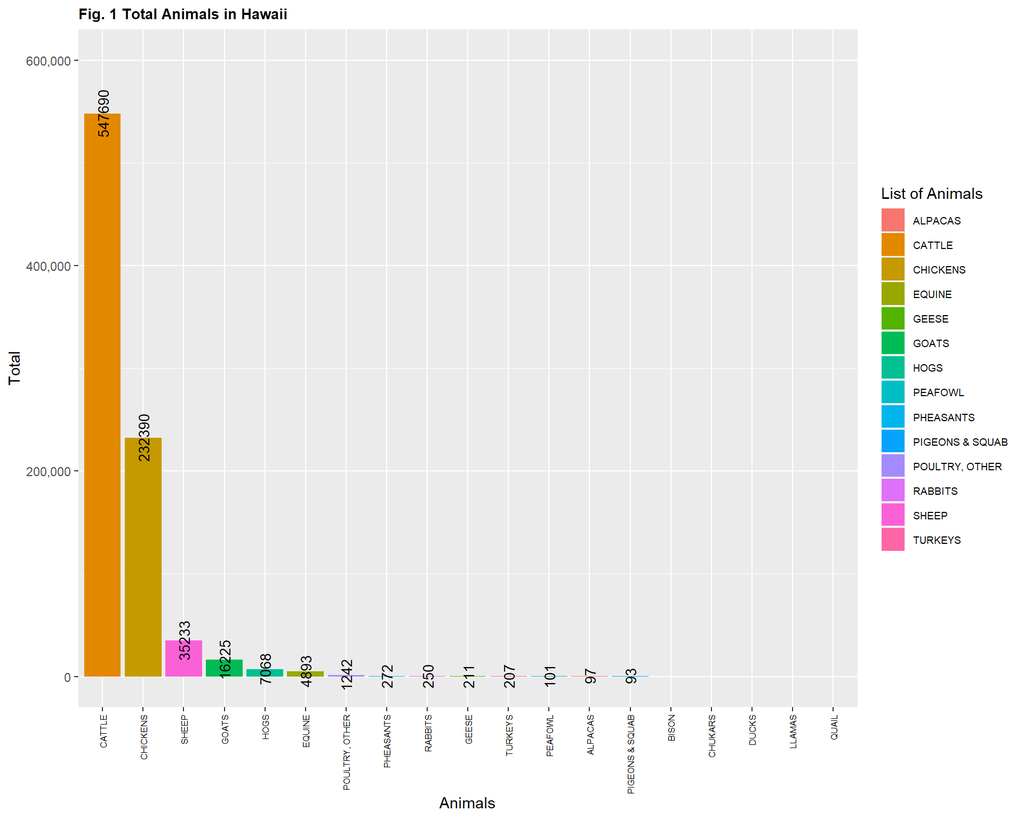

```r
#Create plots for fitted_data
p1 <- ggplot(data = animal_dataFinal, aes(x = reorder(Animal_Type, -Total), y = Total)) + geom_bar(stat='identity',aes(fill=animal_dataFinal$Animal_Type)) + ggtitle('Fig. 1 Total Animals in Hawaii') + scale_x_discrete(labels=animal_dataFinal$Animal_Type, name= 'Animals')+scale_fill_discrete(name = "List of Animals") + scale_y_continuous(labels = comma, name="Total", limits=c(0, 600000))+
  theme(plot.title = element_text(size = 10, face = "bold"),legend.text = element_text( size = 7),axis.text.x = element_text(size = 6,angle = 90, vjust = 0.5, hjust=1,color = "Black"))+ geom_text(aes(label=Total,y =Total + 0.5), size=3.5, angle = 90)

#Final fitted plot
plot(p1)
```

## Animal Sales

```r
#Create a new data frame to filter just the animals sold
animal_sales <- dtotal%>%
  group_by(data.item)%>%
  select(commodity, data.item, value)%>%
  filter(str_detect(commodity, pattern))%>%
  filter(!str_detect(data.item, "OPERATION"))%>%
  filter(str_detect(data.item, "$"))%>%
  filter(!str_detect(data.item, "HEAD"))%>%
  filter(!str_detect(data.item, "INVENTORY"))%>%
  filter(!str_detect(data.item, "LB"))%>%
  arrange(data.item)
```

```r
#Find the sum of number of animals sold by each animal commodity
sum1 <- aggregate(x=animal_sales$value,
                 by = list(animal_sales$commodity),
                 FUN = sum)
```

```r
#Create the sales data frame for the dollar values
animal_sales1 <- dtotal%>%
  group_by(commodity)%>%
  select(commodity, data.item, value)%>%
  filter(str_detect(commodity, pattern))%>%
  filter(str_detect(data.item, "SALE"))%>%
  filter(!str_detect(data.item, "HEAD"))%>%
  filter(!str_detect(data.item, "INVENTORY"))%>%
  filter(!str_detect(data.item, "MEASURED IN"))%>%
  arrange(data.item)
```

```r
#Create a data frame for the total sales by animal
sum2 <- aggregate(x=animal_sales1$value,
                             by = list(animal_sales1$commodity),
                             FUN = sum)
sum2[,2][sum2[,2] == 0] <-NA
```

```r
#Merge the two sum data frames
sum3 <- merge(x=sum2, y = sum1, by = "Group.1", all.x = TRUE)
```

```r
#Create the final sales data frame to view total sales in dollars and total sales in number of animals sold
animal_salesFinal <- sum3%>%
  select(Group.1, x.x, x.y)%>%
  arrange(desc(x.y))%>%
  dplyr::rename(AnimalType = Group.1, TotalNumSales = x.x, TotalinDollars = x.y)
```

### Table for Animal Sales

```r
#Create a table for the sale of animals
TableData <- animal_salesFinal %>%
  gt()%>%
  fmt_currency(
    columns = 3,
    rows = 1:7,
    currency = "USD"
  )%>%
  tab_header(
    title = md("Total Animal Sales in Hawaii"),
    subtitle = "For Hawaii County, Hawaii in 2017")%>%
  tab_source_note(md('*Source: USDA NASS Agriculture'))%>%
  tab_footnote(
    footnote = "No numerical information given",
    location = cells_body(
      columns = 3,
      rows = 8:17
    )
  )%>%
  tab_style(
    style = list(
      cell_fill(color = "#D9E1F2"),
      cell_text(weight = "bold")
    ),
    locations = cells_column_labels(
      columns = vars(TotalNumSales, TotalinDollars, AnimalType)
    )

                  )
TableData
```

Total Animal Sales in Hawaii

| AnimalType | TotalNumSales | TotalinDollars |
| --- | --- | --- |
| CATTLE | 3182 | $34,639,000.00 |
| EQUINE | 98 | $812,000.00 |
| SHEEP | 205 | $798,000.00 |
| GOATS | 225 | $533,000.00 |
| SPECIALTY ANIMALS, OTHER | 10 | $70,000.00 |
| RABBITS | 5 | $5,000.00 |
| ALPACAS | 5 | $4,000.00 |
| BISON | 2 | 0<sup>1</sup> |
| HOGS | 310 | 0<sup>1</sup> |
| CHICKENS | 177 | NA<sup>1</sup> |
| DUCKS | 37 | NA<sup>1</sup> |
| GEESE | 3 | NA<sup>1</sup> |
| PEAFOWL | 1 | NA<sup>1</sup> |
| PHEASANTS | 3 | NA<sup>1</sup> |
| POULTRY TOTALS | 425 | NA<sup>1</sup> |
| POULTRY, OTHER | 85 | NA<sup>1</sup> |
| TURKEYS | 5 | NA<sup>1</sup> |

*Source: USDA NASS Agriculture  
<sup>*1*</sup> No numerical information given

### Graph for Animal Sales

**ggarrange** is used to arrange multiple ggplots on a same page.

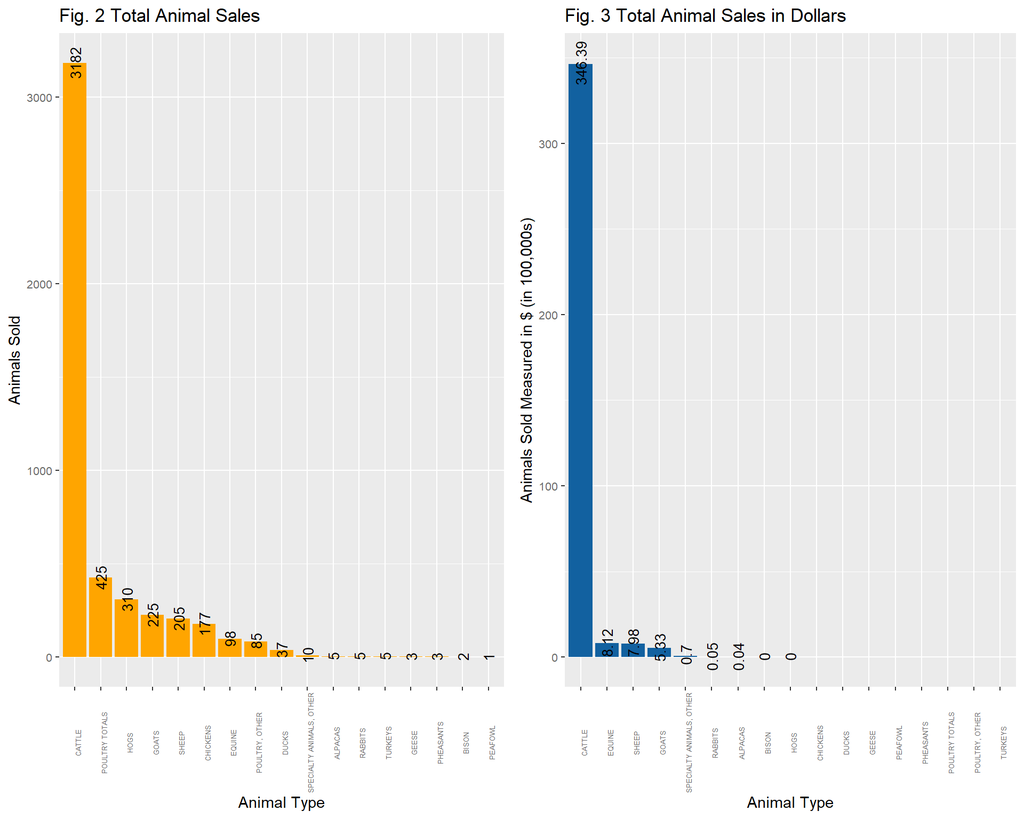

```r
#Create plots for fitted_data
SalesColor <- "#FFA500"
DollarsColor <- '#1261A0'

p3 <- ggplot(animal_salesFinal, aes(x = reorder(AnimalType, -TotalNumSales), y = TotalNumSales, fill = AnimalType)) + labs(x = "Animal Type", y= "Animals Sold") + geom_bar(stat = "identity", width = 0.9, fill = SalesColor) + ggtitle('Fig. 2 Total Animal Sales') + theme(axis.text.x = element_text(color="#696969", size=5, angle=90), axis.text.y = element_text(color='#696969', size=8)) + geom_text(aes(label=TotalNumSales,y =TotalNumSales + 0.5), size=3.5, angle = 90)

p4 <- ggplot(animal_salesFinal, aes(x = reorder(AnimalType, -TotalinDollars), y = TotalinDollars/100000, fill = AnimalType)) + labs(x = "Animal Type", y= "Animals Sold Measured in $ (in 100,000s)") + geom_bar(stat = "identity", width = 0.9, fill = DollarsColor) + ggtitle('Fig. 3 Total Animal Sales in Dollars') + theme(axis.text.x = element_text(color="#696969", size=5, angle=90), axis.text.y = element_text(color='#696969', size=8))+geom_text(aes(label=TotalinDollars/100000,y =TotalinDollars/100000 + 0.5), size=3.5, angle = 90)

p5 <- ggarrange(p3,p4)

#Final fitted plot
plot(p5)
```

# Further Resources

**For Table:**

- [**gt()**](https://gt.rstudio.com/articles/intro-creating-gt-tables.html)
- [**tab_header**](https://www.rdocumentation.org/packages/gt/versions/0.2.2/topics/tab_header)
- [**tab_source_note**](https://www.rdocumentation.org/packages/gt/versions/0.2.2/topics/tab_source_note)
- [**tab_footnote**](https://www.rdocumentation.org/packages/gt/versions/0.2.2/topics/tab_footnote)
- [**tab_style**](https://www.rdocumentation.org/packages/gt/versions/0.2.2/topics/tab_style)
- [**fmt_currency**](https://www.rdocumentation.org/packages/gt/versions/0.2.2/topics/fmt_currency)

**For Bar Graph:**

- [**geom_bar**](https://ggplot2.tidyverse.org/reference/geom_bar.html)
- [**ggtitle**](https://ggplot2.tidyverse.org/reference/labs.html)
- [**scale_x_discrete** and **scale_y_discrete**](https://www.rdocumentation.org/packages/ggplot2/versions/1.0.1/topics/scale_x_discrete)
- [**scale_x_continuous** and **scale_y_continuous**](https://www.rdocumentation.org/packages/ggplot2/versions/1.0.0/topics/scale_x_continuous)
- [**theme**](https://ggplot2.tidyverse.org/reference/theme.html)
- [**geom_text** and **geom_label**](https://ggplot2.tidyverse.org/reference/geom_text.html)

# Works Cited

This code through references and cites the following sources:

- Source I. [USDA - Wikipedia](https://en.wikipedia.org/wiki/United_States_Department_of_Agriculture)
- Source II. [Tidyverse - Packages](https://www.tidyverse.org/packages/)